# bayes proj

Josh Upadhyay

4/28/2020

Other methods currently in use for model selection include the Akaike Information Criterion, or AIC. This method is most simply thought of as a measure of model ‘balance’, weighing a model’s ability to fit the given data while also considering the possibility for overfitting. The lower AIC score, the better. The AIC equation is given as:

$$AIC = -2 ln(L) + 2k$$

Where $L$ is the model’s maximum log-likehood estimate, and $k$ is the number of parameters in the model. While a high log-likelihoods help to decrease AIC, generally these are achieved through more parameters. Of course, the AIC value of a model is only relevant when compared to the AIC for other models. Given multiple models $i$, you can estimate the probability a model $i$ minimizes information loss as such:

$$P_i = e^{(AIC_{min} - AIC_i)/2)}$$

Where $AIC_{min}$ is the lowest score in the set of models.

Bayesian Model Averaging uses a slightly different method for model selection, known as Leave-One-Out (LOO). A single data point $d_{out}$ is excluded from the dataset while a model $i$ is trained on the rest. The model is then used to predict on $d_{out}$, and the residual is calculated. This is repeated muliple times and the error metric is averaged for each model. (Note: AIC approaches LOO with large samples.)

While exact LOO requires $n$ iterations, one for each point in $y$, Pseudo-BMA reduces computational complexity by taking samples from the posterior distribution $S$.

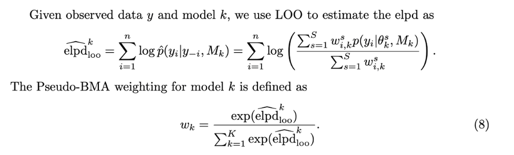

The MAP for each data point $1 \rightarrow n$ (outer sum) is then added for a measure of model $k$’s *expected log pointwise predictive density* (elpd).

^^ okay so this weighting refers to which model is the ‘best’?